# 2022 WolfTicketsAI Evaluation

2022 was a big year for WolfTicketsAI, growing from a small idea and prototype to an active member of the Reddit mmasportsbetting community to a full commercial venture by August. During this there were a number of outstanding victories and technical challenges. Throughout all of it I have tried to provide as much visiblity as I could to how the models function, what data is used, and you all have paid me back many times over.

Most recently in early November a member noticed that the predictions had started to drift in performance and it led me down a road to rebuild the models of WolfTicketAI from the ground up.

Now we have full unit test coverage of all features, robust data pipelines that validate there is no information leaking from the future to any point we choose to evaluate in 2022 and beyond.

With those abilities now comes this notebook, a full record of each prediction that was possible to generate in 2022, from both a model leveraging odds data and one that does not. That data is provided as a CSV along with this notebook to allow you all to explore the outputs to the fullest as we go into 2023.

For 2023, the first priority is to get these models back into production on the site and to automate the insights shown here onto the platform.

Feel free to share this notebook and any analysis with anyone you'd like. Also It will be hosted on GitHub for you to fork, create issues, suggest improvements, etc.

## Getting Started

First up, importing the libraries that are needed to render our charts, This has been kept light with just standard Python Data Science tools.

```python
import pandas as pd
import numpy as np
import matplotlib.pyplot as plt
from matplotlib.ticker import FuncFormatter
import seaborn as sns
```

Now configure the size of plots for later:

```python
sns.set_style("whitegrid")
plt.rcParams["figure.figsize"] = (20,10)
```

Lastly before reading the data, establish a baseline for predictions, they are binary in nature ( 0 means fighter 2 wins, 1 means fighter 1 wins ).

```python
baseline = .5
```

## Loading the Data

Everything is provided as a CSV, so read it with Pandas to get started.

```python
results_df = pd.read_csv("2022_full_predictions.csv")
```

Take a quick peak at a random data point:

```python
results_df.sample(1)
```

|  | fight_id | date_of_fight | event | fighter_1 | fighter_2 | fighter_1_odds | fighter_2_odds | weight_class | main_card_prediction | winner | vegas_model_prediction | vegas_model_score | vegas_model_confidence | vegas_model_correct | model_prediction | model_score | model_confidence | model_correct |
| --- | --- | --- | --- | --- | --- | --- | --- | --- | --- | --- | --- | --- | --- | --- | --- | --- | --- | --- |
| 102 | 6231 | 2022-04-16 | UFC Fight Night: Luque vs. Muhammad | Alatengheili | Kevin Croom | -190 | 140 | Bantamweight | False | Alatengheili | Alatengheili | 0.646979 | 14.697856 | True | Alatengheili | 0.669032 | 16.903156 | True |

## Evaluating Performance

With the data loaded, it is now possible to see the performance from each model.

Create a dataframe for each model's results so they can be reviewed.

We will refer to them below as the Vegas Model when discussing the model that used odds data, and WolfTicketsAI Model to refer to the model that was not trained using odds data at all.

```python
# The model with odds
vegas_df = results_df.copy(deep=True)
vegas_columns = ["fight_id", "date_of_fight",
                 "event", "fighter_1", "fighter_2", "fighter_1_odds",
                 "fighter_2_odds", "weight_class", "main_card_prediction",
                 "winner", "vegas_model_prediction", "vegas_model_score",
                 "vegas_model_confidence", "vegas_model_correct"]
vegas_df = vegas_df[vegas_columns]
# The model without odds
wt_df = results_df.copy(deep=True)
wt_columns = ["fight_id", "date_of_fight",
                 "event", "fighter_1", "fighter_2", "fighter_1_odds",
                 "fighter_2_odds", "weight_class", "main_card_prediction",
                 "winner", "model_prediction", "model_score",
                 "model_confidence", "model_correct"]
wt_df = wt_df[wt_columns]

# Clean up columns for common use later:
vegas_df = vegas_df.rename(columns={
    "vegas_model_confidence": "confidence",
    "vegas_model_prediction": "prediction",
    "vegas_model_score": "score",
    "vegas_model_correct": "correct",

})

wt_df = wt_df.rename(columns={
    "model_confidence": "confidence",
    "model_prediction": "prediction",
    "model_score": "score",
    "model_correct": "correct",

})
```

To quickly see their accuracy use the value_counts function:

```python
vegas_df['correct'].value_counts(normalize=True)
```

```
True     0.658711
False    0.341289
Name: correct, dtype: float64
```

```python
wt_df['correct'].value_counts(normalize=True)
```

```
True     0.599045
False    0.400955
Name: correct, dtype: float64
```

Not the greatest results ever, we see 65.8% correct for the Vegas model and 59.9% correct for the model without odds. This does not tell a full story.

Now remove any prediction with a score of 0(indicating it was really a cointoss that we would not have bet on). Then repeat the initial assessment.

```python
vegas_df = vegas_df[vegas_df['confidence']>=1]
vegas_df['correct'].value_counts(normalize=True)
```

```
True     0.674185
False    0.325815
Name: correct, dtype: float64
```

```python
wt_df = wt_df[wt_df['confidence']>=1]
wt_df['correct'].value_counts(normalize=True)
```

```
True     0.60396
False    0.39604
Name: correct, dtype: float64
```

That improved things to 67.4% and 60.4% relatively. These are an OK start but they tell us we probably wouldn't just want to bet blindly with predictions using these models.

Let's take a deeper look at accuracy from each of the models.

### Accuracy By Corner

WolfTicketsAI predictions for both models eventually break down into a 0(blue corner wins) or 1(red corner wins) prediction. Before we explore specific accuracy results by confidence or specific returns, this view allows us to better assume when to leverage a prediction.

```python
vegas_red_df = vegas_df[vegas_df['prediction']==vegas_df['fighter_1']]
vegas_blue_df = vegas_df[vegas_df['prediction']==vegas_df['fighter_2']]
vegas_red_accuracy = vegas_red_df['correct'].value_counts(normalize=True)[True]
vegas_blue_accuracy = vegas_blue_df['correct'].value_counts(normalize=True)[True]
print(f"Vegas Red Corner Accuracy: ", round(vegas_red_accuracy*100,2),"%")
print(f"Vegas Blue Corner Accuracy: ", round(vegas_blue_accuracy*100,2),"%")
```

```
Vegas Red Corner Accuracy:  69.51 %
Vegas Blue Corner Accuracy:  64.05 %
```

```python
wt_red_df = wt_df[wt_df['prediction']==wt_df['fighter_1']]
wt_blue_df = wt_df[wt_df['prediction']==wt_df['fighter_2']]
wt_red_accuracy = wt_red_df['correct'].value_counts(normalize=True)[True]
wt_blue_accuracy = wt_blue_df['correct'].value_counts(normalize=True)[True]
print(f"WT Red Corner Accuracy: ", round(wt_red_accuracy*100,2),"%")
print(f"WT Blue Corner Accuracy: ", round(wt_blue_accuracy*100,2),"%")
```

```
WT Red Corner Accuracy:  63.1 %
WT Blue Corner Accuracy:  54.89 %
```

What about the fights in general?

```python
vegas_df['red_wins'] = (vegas_df['fighter_1']==vegas_df['winner']).astype(bool)
gen_red_accuracy = vegas_df['red_wins'].value_counts(normalize=True)[True]
gen_blue_accuracy = vegas_df['red_wins'].value_counts(normalize=True)[False]
print(f"Red Corner Winning Percentage: ", round(gen_red_accuracy*100,2),"%")
print(f"Blue Corner Winning Percentage: ", round(gen_blue_accuracy*100,2),"%")
```

```
Red Corner Winning Percentage:  56.64 %
Blue Corner Winning Percentage:  43.36 %
```

### Accuracy By Confidence Score

Here we will determine the accuracy of each model as we explore their confidence scores from 1 to their max observed.

Initially let's take a look at a histogram of each to better see the ranges of predictions.

The histograms plot the total number of True and False predictions at each confidence interval.

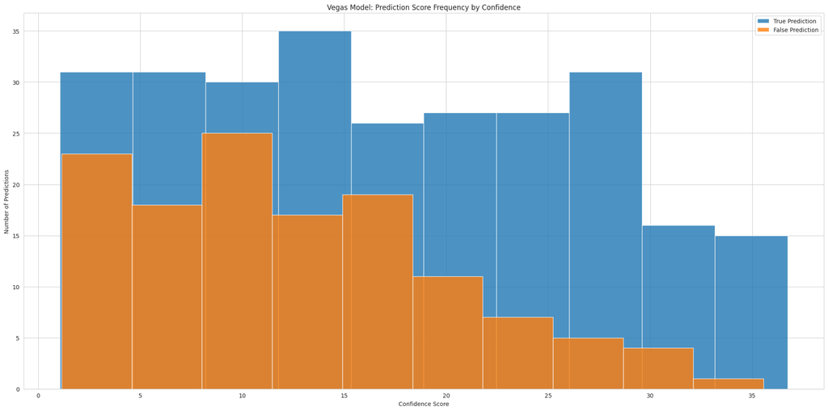

```python
true_prediction = vegas_df['correct']  == True
false_prediction = vegas_df['correct']== False

plt.title('Vegas Model: Prediction Score Frequency by Confidence')

plt.hist(vegas_df['confidence'][true_prediction],label='True Prediction', alpha=0.8)
plt.hist(vegas_df['confidence'][false_prediction],label='False Prediction', alpha=0.8)

plt.legend(loc='upper right')

plt.xlabel('Confidence Score')
plt.ylabel('Number of Predictions')

plt.tight_layout()

plt.show()
```

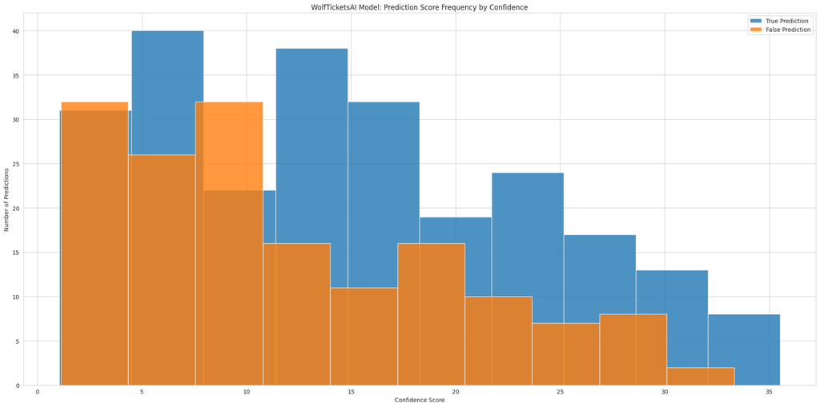

```python
true_prediction = wt_df['correct']  == True
false_prediction = wt_df['correct']== False

plt.title('WolfTicketsAI Model: Prediction Score Frequency by Confidence')

plt.hist(wt_df['confidence'][true_prediction],label='True Prediction', alpha=0.8)
plt.hist(wt_df['confidence'][false_prediction],label='False Prediction', alpha=0.8)

plt.legend(loc='upper right')

plt.xlabel('Confidence Score')
plt.ylabel('Number of Predictions')

plt.tight_layout()

plt.show()
```

In both models see a general trend of improved performance in accuracy as the confidence score rises. We also note that there were more False predictions from 0->5 and 5->10 for the WolfTicketsAI model.

The really big thing to notice is that there are fewer predictions of higher confidence in both cases, this will be relevant when considering betting strategies later.

```python
odds_confidence = []
# start by iterating over confidence scores
for x in range (0,35):
    # first create a df that focuses on the confidence score in question
    conf_df = vegas_df[vegas_df['confidence']>=x]
    # next break it down into main and under cards
    main_df = conf_df[conf_df['main_card_prediction']==True]
    under_df = conf_df[conf_df['main_card_prediction']==False]
    result = {}
    result['confidence'] = x
    try:
        result['full_card'] = conf_df['correct'].value_counts(normalize=True)[1]
    except:
        result['full_card'] = None
    try:
        result['main_card'] = main_df['correct'].value_counts(normalize=True)[1]
    except:
        result['main_card'] = None
    try:
        result['under_card'] = under_df['correct'].value_counts(normalize=True)[1]
    except:
        result['under_card'] = None
    odds_confidence.append(result)
vegas_accuracy_by_confidence = pd.DataFrame.from_records(odds_confidence, index='confidence')
```

```
(0.0, 35.0)
```

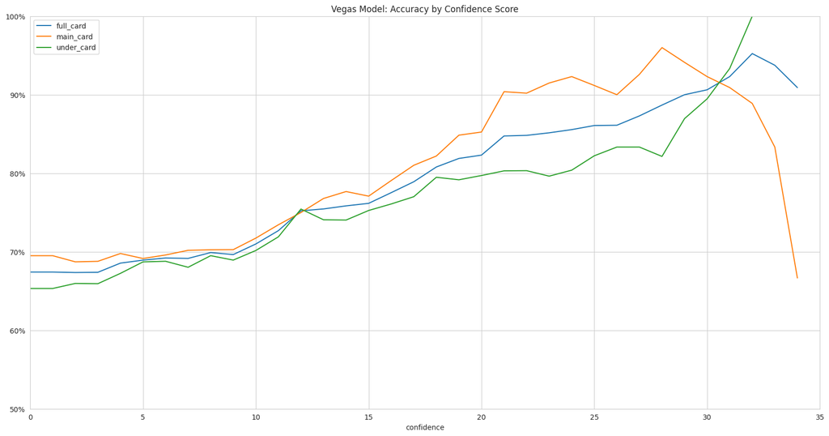

```python
ax = vegas_accuracy_by_confidence.plot()
ax.set_title("Vegas Model: Accuracy by Confidence Score")
ax.set_ylim(0.5, 1.0)
ax.yaxis.set_major_formatter(FuncFormatter(lambda y, _: '{:.0%}'.format(y)))
ax.set_xlim(0,35)
```

```python
no_odds_confidence = []
# start by iterating over confidence scores
for x in range (0,35):
    # first create a df that focuses on the confidence score in question
    conf_df = wt_df[wt_df['confidence']>=x]
    # next break it down into main and under cards
    main_df = conf_df[conf_df['main_card_prediction']==True]
    under_df = conf_df[conf_df['main_card_prediction']==False]
    result = {}
    result['confidence'] = x
    try:
        result['full_card'] = conf_df['correct'].value_counts(normalize=True)[1]
    except:
        result['full_card'] = None
    try:
        result['main_card'] = main_df['correct'].value_counts(normalize=True)[1]
    except:
        result['main_card'] = None
    try:
        result['under_card'] = under_df['correct'].value_counts(normalize=True)[1]
    except:
        result['under_card'] = None
    no_odds_confidence.append(result)
wolftickets_accuracy_by_confidence = pd.DataFrame.from_records(no_odds_confidence, index='confidence')
```

```
(0.0, 35.0)
```

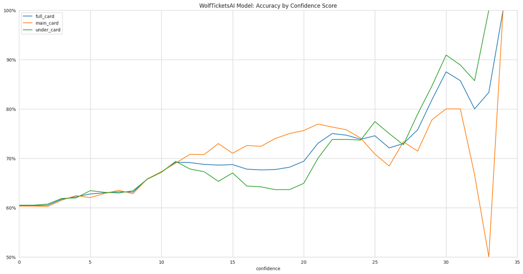

```python
ax = wolftickets_accuracy_by_confidence.plot()
ax.set_title("WolfTicketsAI Model: Accuracy by Confidence Score")
ax.set_ylim(0.5, 1.0)
ax.yaxis.set_major_formatter(FuncFormatter(lambda y, _: '{:.0%}'.format(y)))
ax.set_xlim(0,35)
```

So what we see here is a nice trend in accuracy going up for the Vegas model but a series of points between 30 and 35 confidence scores for the WolfTicketAI model dropping in performance on the main card.

To dig into these specific predictions:

```python
# Set a confidence threshold and render the results
wt_df[(wt_df['confidence']>=30) & (wt_df['correct']==False)]
```

|  | fight_id | date_of_fight | event | fighter_1 | fighter_2 | fighter_1_odds | fighter_2_odds | weight_class | main_card_prediction | winner | prediction | score | confidence | correct |
| --- | --- | --- | --- | --- | --- | --- | --- | --- | --- | --- | --- | --- | --- | --- |
| 286 | 6507 | 2022-08-20 | UFC 278: Usman vs. Edwards | Kamaru Usman | Leon Edwards | -380 | 260 | UFC Welterweight Title | True | Leon Edwards | Kamaru Usman | 0.833182 | 33.318192 | False |
| 317 | 6551 | 2022-10-01 | UFC Fight Night: Dern vs. Yan | John Castaneda | Daniel Santos | -195 | 150 | Catch Weight | False | Daniel Santos | John Castaneda | 0.824702 | 32.470167 | False |

That's 2 predictions, the Usman loss I'll never lose sleep over getting wrong and Catch Weight matches can be tricky. Perhaps it would be worth it to explore results over weight class at a later date.

Before turning over to specific rates of return, what if we looked at the accuracy by confidence score when both models vote together?

### Accuracy Using Both Models

To do this we will first restrict the dataframe to only items where the correct fields agreed. Then we will create a confidence score of averages before plotting.

```python
joint_df = results_df.copy(deep=True)
# Rename one of the correctness columns for consistency later
joint_df = joint_df.rename(columns={
    "vegas_model_correct": "correct",
})
joint_df = joint_df[joint_df['correct'] == joint_df['model_correct']]
joint_df['confidence'] = joint_df[['vegas_model_confidence', 'model_confidence']].mean(axis=1)
```

```python
joint_confidence = []
# start by iterating over confidence scores
for x in range (0,41):
    # first create a df that focuses on the confidence score in question
    conf_df = joint_df[joint_df['confidence']>=x]
    # next break it down into main and under cards
    main_df = conf_df[conf_df['main_card_prediction']==True]
    under_df = conf_df[conf_df['main_card_prediction']==False]
    result = {}
    result['confidence'] = x
    try:
        result['full_card'] = conf_df['correct'].value_counts(normalize=True)[1]
    except:
        result['full_card'] = None
    try:
        result['main_card'] = main_df['correct'].value_counts(normalize=True)[1]
    except:
        result['main_card'] = None
    try:
        result['under_card'] = under_df['correct'].value_counts(normalize=True)[1]
    except:
        result['under_card'] = None
    joint_confidence.append(result)
joint_accuracy_by_confidence = pd.DataFrame.from_records(joint_confidence, index='confidence')
```

```
(0.0, 35.0)
```

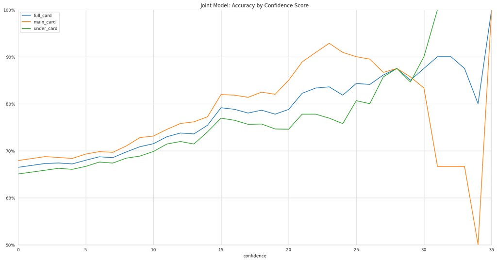

```python
ax = joint_accuracy_by_confidence.plot()
ax.set_title("Joint Model: Accuracy by Confidence Score")
ax.set_ylim(0.5, 1.0)
ax.yaxis.set_major_formatter(FuncFormatter(lambda y, _: '{:.0%}'.format(y)))
ax.set_xlim(0,35)
```

Also pretty promising for a strategy where accuracy is trending from above 65% all along and it mostly rises steadily(except after 30 again). Also consider again the drop in the number of predictions, a few wrong at this level can erase your accuracy completely.

Now onto the important bit, returns.

## Returns from Models and Strategies

A return is calculated based on the amount of money returned beyond the original bet if positive and is a negative percentage for anything lost. Where a bet is an individual wager on at least one fight.

We will evaluate performance over 3 models:

1. Vegas Model
2. WolfTicketsAI Model
3. Joint Model

For each of the models we will evaluate the following strategies:

1. Even betting on the full card
2. Even betting on the main card
3. Even betting on the under card
4. Betting on the most confident 2 predictions
5. Betting on the most confident 3 predictions
6. Parlaying the most confident 2 predictions
7. Parlaying the most confident 3 predictions

Each of those furthermore will be explored over the model's confidence score.

We will assume a standard wager of $10.00 per bet on each prediction, there are obviously more nuanced approaches but this is just a start.

### Convert American Odds to Decimal

The odds stored in the CSV were American odds and not in a common format for rendering returns, this code will add a decimal odds column.

```python
def convert_odds_to_decimal(odds_in_american):
    """
    # For positive:
    Decimal odds = (US odds/100) +1
    # For negative:
    Decimal odds = (100/US odds) + 1
    """
    if odds_in_american > 0:
        dec_odds = (odds_in_american / 100.0) + 1
    else:
        dec_odds = (100.0/(-1 * odds_in_american)) + 1
    return dec_odds
```

```python
# Vegas Model
vegas_df['dec_odds'] = None
vegas_df['money_returned'] = None
for i, row in vegas_df.iterrows():
    # Determine the correct fighter for odds
    odds = row['fighter_1_odds']
    if row['winner'] == row['fighter_2']:
        odds = row['fighter_2_odds']
    dec_odds = convert_odds_to_decimal(odds)
    vegas_df.at[i, 'dec_odds'] = dec_odds
    vegas_df.at[i, 'money_returned'] = 0.0
    if row['correct'] == True:
        vegas_df.at[i, 'money_returned'] = (10 * dec_odds)


# WolfTicketsAI Model
wt_df['dec_odds'] = None
wt_df['money_returned'] = None
for i, row in wt_df.iterrows():
    # Determine the correct fighter for odds
    odds = row['fighter_1_odds']
    if row['winner'] == row['fighter_2']:
        odds = row['fighter_2_odds']
    dec_odds = convert_odds_to_decimal(odds)
    wt_df.at[i, 'dec_odds'] = dec_odds
    wt_df.at[i, 'money_returned'] = 0.0
    if row['correct'] == True:
        wt_df.at[i, 'money_returned'] = (10 * dec_odds)


# Joint Model
joint_df['dec_odds'] = None
joint_df['money_returned'] = None
for i, row in joint_df.iterrows():
    # Determine the correct fighter for odds
    odds = row['fighter_1_odds']
    if row['winner'] == row['fighter_2']:
        odds = row['fighter_2_odds']
    dec_odds = convert_odds_to_decimal(odds)
    joint_df.at[i, 'dec_odds'] = dec_odds
    joint_df.at[i, 'money_returned'] = 0.0
    if row['correct'] == True:
        joint_df.at[i, 'money_returned'] = (10 * dec_odds)
```

```python
# Checkout out a sample of a few rows to make sure it looks right:
test = vegas_df.sample(2)
test[['dec_odds']].prod()[0]

vegas_df
```

|  | fight_id | date_of_fight | event | fighter_1 | fighter_2 | fighter_1_odds | fighter_2_odds | weight_class | main_card_prediction | winner | prediction | score | confidence | correct | red_wins | dec_odds | money_returned |
| --- | --- | --- | --- | --- | --- | --- | --- | --- | --- | --- | --- | --- | --- | --- | --- | --- | --- |
| 0 | 6020 | 2022-01-15 | UFC Fight Night: Kattar vs. Chikadze | TJ Brown | Charles Rosa | -250 | 170 | Lightweight | False | TJ Brown | TJ Brown | 0.741756 | 24.175572 | True | True | 1.4 | 14.0 |
| 1 | 6059 | 2022-01-15 | UFC Fight Night: Kattar vs. Chikadze | Brian Kelleher | Kevin Croom | -500 | 255 | Featherweight | False | Brian Kelleher | Brian Kelleher | 0.689111 | 18.911147 | True | True | 1.2 | 12.0 |
| 2 | 6060 | 2022-01-15 | UFC Fight Night: Kattar vs. Chikadze | Court McGee | Ramiz Brahimaj | -110 | -130 | Welterweight | False | Court McGee | Court McGee | 0.728707 | 22.870708 | True | True | 1.909091 | 19.090909 |
| 3 | 6064 | 2022-01-15 | UFC Fight Night: Kattar vs. Chikadze | Katlyn Chookagian | Jennifer Maia | -240 | 145 | Women's Flyweight | True | Katlyn Chookagian | Katlyn Chookagian | 0.675604 | 17.560387 | True | True | 1.416667 | 14.166667 |
| 5 | 6066 | 2022-01-15 | UFC Fight Night: Kattar vs. Chikadze | Jake Collier | Chase Sherman | -140 | 110 | Heavyweight | True | Jake Collier | Jake Collier | 0.614103 | 11.410332 | True | True | 1.714286 | 17.142857 |
| ... | ... | ... | ... | ... | ... | ... | ... | ... | ... | ... | ... | ... | ... | ... | ... | ... | ... |
| 413 | 6647 | 2022-12-17 | UFC Fight Night: Cannonier vs. Strickland | Cheyanne Vlismas | Cory McKenna | -200 | 154 | Women's Strawweight | False | Cory McKenna | Cheyanne Vlismas | 0.596712 | 9.671235 | False | False | 2.54 | 0.0 |
| 414 | 6648 | 2022-12-17 | UFC Fight Night: Cannonier vs. Strickland | Cody Brundage | Michal Oleksiejczuk | 195 | -290 | Middleweight | True | Michal Oleksiejczuk | Michal Oleksiejczuk | 0.322362 | 17.763793 | True | False | 1.344828 | 13.448276 |
| 416 | 6650 | 2022-12-17 | UFC Fight Night: Cannonier vs. Strickland | Alex Caceres | Julian Erosa | 140 | -180 | Featherweight | True | Alex Caceres | Julian Erosa | 0.337632 | 16.236785 | False | True | 2.4 | 0.0 |
| 417 | 6652 | 2022-12-17 | UFC Fight Night: Cannonier vs. Strickland | Arman Tsarukyan | Damir Ismagulov | -220 | 155 | Lightweight | True | Arman Tsarukyan | Arman Tsarukyan | 0.631165 | 13.116479 | True | True | 1.454545 | 14.545455 |
| 418 | 6653 | 2022-12-17 | UFC Fight Night: Cannonier vs. Strickland | Jared Cannonier | Sean Strickland | -125 | -110 | Middleweight | True | Jared Cannonier | Sean Strickland | 0.465366 | 3.463376 | False | True | 1.8 | 0.0 |

399 rows × 17 columns

### Compute Performance of Strategies over Confidence Intervals

#### Vegas Model

```python
# Creating functions to return performance of various strategies:

def safe_division(x, y):
    result = 0
    if y != 0:
        result = x / (y * 1.0)
    return result


def get_even_betting_returns_full_card(df):
    returns = df['money_returned'].sum()
    return safe_division(returns, (df.shape[0] * 10))


def get_even_betting_returns_main_card(df):
    main_df = df[df['main_card_prediction']==True]
    returns = main_df['money_returned'].sum()
    return safe_division(returns, (main_df.shape[0] * 10))


def get_even_betting_returns_under_card(df):
    under_df = df[df['main_card_prediction']==False]
    returns = under_df['money_returned'].sum()
    return safe_division(returns, (under_df.shape[0] * 10))


def get_top_2_confident_returns_per_event(df):
    """
    Slightly more involved than the previous ones, requires iterating
    over each event first.
    """
    # Get a list of all of the events:
    events = df['event'].unique()
    # Set initial returns
    returns = 0.0
    # Iterate over each event computing the top results
    for event in events:
        event_df = df[df['event']==event]
        # Find the most confident predictions
        event_df = event_df.nlargest(2,'confidence')
        returns += event_df['money_returned'].sum()
    return safe_division(returns, (len(events) * 2 * 10))


def get_top_3_confident_returns_per_event(df):
    """
    Slightly more involved than the previous ones, requires iterating
    over each event first.
    """
    # Get a list of all of the events:
    events = df['event'].unique()
    # Set initial returns
    returns = 0.0
    # Iterate over each event computing the top results
    for event in events:
        event_df = df[df['event']==event]
        # Find the most confident predictions
        event_df = event_df.nlargest(3,'confidence')
        returns += event_df['money_returned'].sum()
    return safe_division(returns, (len(events) * 3 * 10))

def get_top_2_parlay_confident_returns_per_event(df):
    """
    Slightly more involved than the previous ones, requires iterating
    over each event first.
    """
    # Get a list of all of the events:
    events = df['event'].unique()
    # Set initial returns
    returns = 0.0
    # Iterate over each event computing the top results
    for event in events:
        event_df = df[df['event']==event]
        # Find the most confident predictions
        event_df = event_df.nlargest(2,'confidence')
        # Check to make sure the individual bets landed
        if (event_df['money_returned'] > 0).all():
            # Calculate the new odds value
            odds = event_df[['dec_odds']].prod()[0]
            returns += 10 * odds
        else:
            pass
    return safe_division(returns, (len(events)  * 10))


def get_top_3_parlay_confident_returns_per_event(df):
    """
    Slightly more involved than the previous ones, requires iterating
    over each event first.
    """
    # Get a list of all of the events:
    events = df['event'].unique()
    # Set initial returns
    returns = 0.0
    # Iterate over each event computing the top results
    for event in events:
        event_df = df[df['event']==event]
        # Find the most confident predictions
        event_df = event_df.nlargest(3,'confidence')
        # Check to make sure the individual bets landed
        if (event_df['money_returned'] > 0).all():
            # Calculate the new odds value
            odds = event_df[['dec_odds']].prod()[0]
            returns += 10 * odds
        else:
            pass
    return safe_division(returns, (len(events)  * 10))
```

```python
vegas_performance_by_confidence = []
# Get the max range of confidence scores for the model
max_x = vegas_df.loc[vegas_df['confidence'].idxmax()]
max_x = int(max_x['confidence'])+1
```

```python
vegas_performance_by_confidence = []
# Iterate over the full range of confidence scores
for x in range (1,max_x):
    # Create a dataframe restricted to the confidence score
    conf_df = vegas_df[vegas_df['confidence']>=x]
    # Create a result dict to hold all findings
    result = {}
    # Set the confidence value:
    result['confidence'] = x
    # Even betting on the full card
    result['full_card_even_betting'] = get_even_betting_returns_full_card(df=conf_df)
    # Even betting on the main card
    result['main_card_even_betting'] = get_even_betting_returns_main_card(df=conf_df)
    # Even betting on the under card
    result['under_card_even_betting'] = get_even_betting_returns_under_card(df=conf_df)
    # Even betting most confident top 2 predictions per event
    result['top_2_most_confident'] = get_top_2_confident_returns_per_event(df=conf_df)
    # Even betting most confident top 2 predictions per event
    result['top_3_most_confident'] = get_top_3_confident_returns_per_event(df=conf_df)
    # Parlaying the top 2 most confident predictions:
    result['top_2_most_confident_parlay'] = get_top_2_parlay_confident_returns_per_event(df=conf_df)
    # Parlaying the top 3 most confident predictions:
    result['top_3_most_confident_parlay'] = get_top_3_parlay_confident_returns_per_event(df=conf_df)

    vegas_performance_by_confidence.append(result)
vegas_performance_by_confidence_df = pd.DataFrame.from_records(vegas_performance_by_confidence, index='confidence')
```

```python
# Do a quick sanity test on math:
# Set confidence to 15
test_df = vegas_df[vegas_df['confidence']>=15]
# get the shape of the df
returns = test_df['money_returned'].sum()
total_wagered = test_df.shape[0] * 10
final_returns = safe_division(returns, total_wagered)
print(f"Shape of dataframe: ")
print(f"Total Wagered: $", round(total_wagered,2))
print(f"Total returned: $", round(returns,2))
print(f"Final Returns: ", round(final_returns*100, 2),"%")
```

```
Shape of dataframe:
Total Wagered: $ 1930
Total returned: $ 1958.16
Final Returns:  101.46 %
```

```
(1.0, 35.0)
```

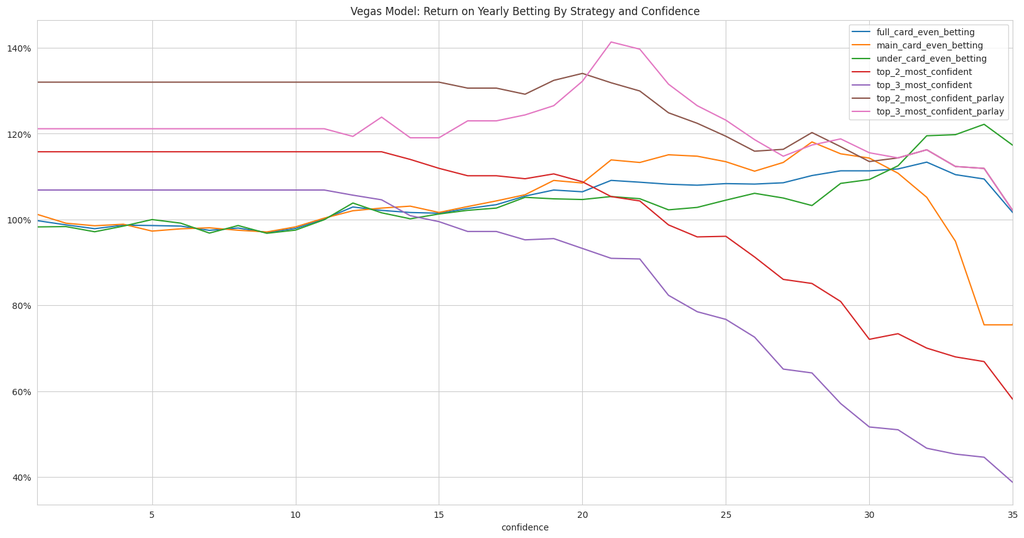

```python
ax = vegas_performance_by_confidence_df.plot()
ax.set_title("Vegas Model: Return on Yearly Betting By Strategy and Confidence")
#ax.set_ylim(0.5, 1.0)
ax.yaxis.set_major_formatter(FuncFormatter(lambda y, _: '{:.0%}'.format(y)))
ax.set_xlim(1,35)
```

#### WolfTicketsAI Model

```python
# Get the max range of confidence scores for the model
max_x = wt_df.loc[wt_df['confidence'].idxmax()]
max_x = int(max_x['confidence'])+1
```

```python
wolfticketsai_performance_by_confidence = []
# Iterate over the full range of confidence scores
for x in range (1,max_x):
    # Create a dataframe restricted to the confidence score
    conf_df = wt_df[wt_df['confidence']>=x]
    # Create a result dict to hold all findings
    result = {}
    # Set the confidence value:
    result['confidence'] = x
    # Even betting on the full card
    result['full_card_even_betting'] = get_even_betting_returns_full_card(df=conf_df)
    # Even betting on the main card
    result['main_card_even_betting'] = get_even_betting_returns_main_card(df=conf_df)
    # Even betting on the under card
    result['under_card_even_betting'] = get_even_betting_returns_under_card(df=conf_df)
    # Even betting most confident top 2 predictions per event
    result['top_2_most_confident'] = get_top_2_confident_returns_per_event(df=conf_df)
    # Even betting most confident top 2 predictions per event
    result['top_3_most_confident'] = get_top_3_confident_returns_per_event(df=conf_df)
    # Parlaying the top 2 most confident predictions:
    result['top_2_most_confident_parlay'] = get_top_2_parlay_confident_returns_per_event(df=conf_df)
    # Parlaying the top 3 most confident predictions:
    result['top_3_most_confident_parlay'] = get_top_3_parlay_confident_returns_per_event(df=conf_df)

    wolfticketsai_performance_by_confidence.append(result)
wolfticketsai_performance_by_confidence_df = pd.DataFrame.from_records(wolfticketsai_performance_by_confidence, index='confidence')
```

```
(1.0, 35.0)
```

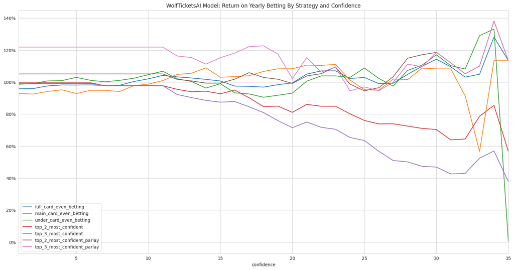

```python
ax = wolfticketsai_performance_by_confidence_df.plot()
ax.set_title("WolfTicketsAI Model: Return on Yearly Betting By Strategy and Confidence")
#ax.set_ylim(0.5, 1.0)
ax.yaxis.set_major_formatter(FuncFormatter(lambda y, _: '{:.0%}'.format(y)))
ax.set_xlim(1,35)
```

#### Joint Model

```python
# Get the max range of confidence scores for the model
max_x = joint_df.loc[joint_df['model_confidence'].idxmax()]
max_x = int(max_x['model_confidence'])+1
```

```python
joint_model_performance_by_confidence = []
# Iterate over the full range of confidence scores
for x in range (1,max_x):
    # Create a dataframe restricted to the confidence score
    conf_df = joint_df[joint_df['confidence']>=x]
    # Create a result dict to hold all findings
    result = {}
    # Set the confidence value:
    result['confidence'] = x
    # Even betting on the full card
    result['full_card_even_betting'] = get_even_betting_returns_full_card(df=conf_df)
    # Even betting on the main card
    result['main_card_even_betting'] = get_even_betting_returns_main_card(df=conf_df)
    # Even betting on the under card
    result['under_card_even_betting'] = get_even_betting_returns_under_card(df=conf_df)
    # Even betting most confident top 2 predictions per event
    result['top_2_most_confident'] = get_top_2_confident_returns_per_event(df=conf_df)
    # Even betting most confident top 2 predictions per event
    result['top_3_most_confident'] = get_top_3_confident_returns_per_event(df=conf_df)
    # Parlaying the top 2 most confident predictions:
    result['top_2_most_confident_parlay'] = get_top_2_parlay_confident_returns_per_event(df=conf_df)
    # Parlaying the top 3 most confident predictions:
    result['top_3_most_confident_parlay'] = get_top_3_parlay_confident_returns_per_event(df=conf_df)

    joint_model_performance_by_confidence.append(result)
joint_model_performance_by_confidence_df = pd.DataFrame.from_records(joint_model_performance_by_confidence, index='confidence')
```

```
(1.0, 35.0)
```

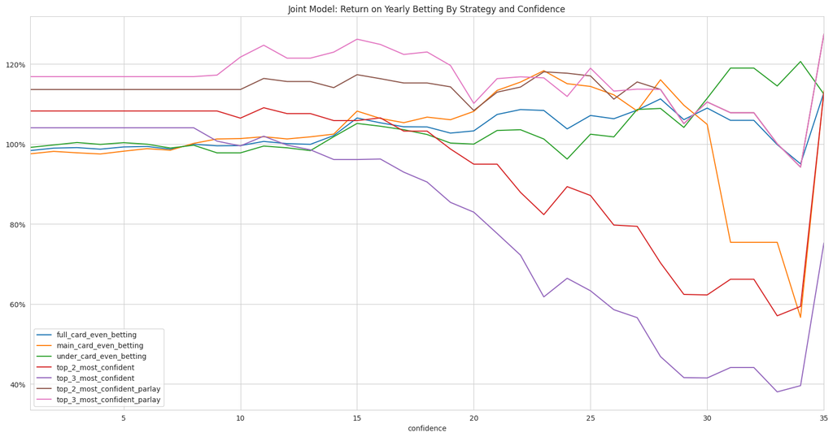

```python
ax = joint_model_performance_by_confidence_df.plot()
ax.set_title("Joint Model: Return on Yearly Betting By Strategy and Confidence")
#ax.set_ylim(0.5, 1.0)
ax.yaxis.set_major_formatter(FuncFormatter(lambda y, _: '{:.0%}'.format(y)))
ax.set_xlim(1,35)
```

```python
# Do a quick sanity test on math:
# Set confidence to 15
test_df = joint_df[joint_df['confidence']>=15]
# get the shape of the df
returns = test_df['money_returned'].sum()
total_wagered = test_df.shape[0] * 10
final_returns = safe_division(returns, total_wagered)
print(f"Shape of dataframe: ")
print(f"Total Wagered: $" , round(total_wagered, 2))
print(f"Total returned: $" , round(returns, 2))
print(f"Final Returns: ", round(final_returns, 2)*100,"%")
```

```
Shape of dataframe:
Total Wagered: $ 1630
Total returned: $ 1736.36
Final Returns:  107.0 %
```

## What Does All This Mean?

For starters, WolfTicketsAI when leveraging odds data delivered a +15% ROI for the entire year when only placing the top 2 most confident bets per event. Various other strategies work even better and this gives a great baseline to improve on for 2023.

### Delivering Predictions

WolfTicketsAI is also going to shift in how results and predictions are communicated, for 2023 it will work like this:

1. Prediction history remains open to all visitors of the site.
2. Prediction explainability, both history and live predictions will be a feature for subscribers only.
3. Predictions using odds data will be a feature for subscribers only.
4. WolfTicketsAI curated bets will be available before an event to subscribers, but anyone can view the performance going forward here: https://www.betmma.tips/wolfticketsaihttps://www.betmma.tips/wolfticketsai
5. Predictions without leveraging odds, and without explainability or confidence will be posted to sites like Reddit for free before the event.

Note, you may be wondering why performance is terrible right now on betmma.tips, for 2022 I was incredibly lazy and did not update it reliably. Consider reliable posting here a new year's resolution.

### Pricing Changes

For 2023, all subscriptions are reduced to 5USD per month. This change has been made already for you if you are an active subscriber, if you sign up going forward it will automatically select the 5USD per month rate.

I look forward to more success, improved modeling, and a greater community around WolfTicketsAI in 2023.

Thanks!

-- Chris King